# PML course project

Ilyas Aaqaoui

29 janvier 2017

# Executive Summary:

Using some devices makes it possible to collect a large amount of data about personal activity relatively inexpensively. These type of devices are part of the quantified self movement. One thing that people regularly do is quantify how much of a particular activity they do, but they rarely quantify how well they do it. In this project, the goal will be to use data from accelerometers on the belt, forearm, arm, and dumbell of 6 participants. They were asked to perform barbell lifts correctly and incorrectly in 5 different ways, and use an algorithm for learning from the data to predict how well a new participant executes a mouvement.

## Part 1: Preparing data

**loading packages**

```r
library(ggplot2)
library(caret)
library(randomForest)
library(Hmisc)
```

**loading data**

```r
trurl = "https://d396qusza40orc.cloudfront.net/predmachlearn/pml-training.csv"
download.file(trurl, destfile = "pml-training.csv")
testurl = "https://d396qusza40orc.cloudfront.net/predmachlearn/pml-testing.csv"
download.file(testurl, destfile = "pml-testing.csv")
```

This [document](http://groupware.les.inf.puc-rio.br/public/papers/2013.Velloso.QAR-WLE.pdf) by the Pontifical Catholic University in Rio provides enough information to understand the situation and more importantly to understand the features used in this dataset.

The outcome/predicted variable is a multi (5) class variable.

We need now to split the given training set training_tot to training and test.

The given testing set that has 20 observations will be used for evaluation and grading:

```r
set.seed(544)
inTrain <- createDataPartition(train$classe, p=0.70, list=F)
training <- train[inTrain,]
test <- train[-inTrain,]
```

## Modelling and Prediction:

Linear regression will not be a good choice for this dataset, we will use Random Forest in two ways, then choose the one with that best balances between accuracy on the test set and computation expense.

#### First model

*Results:*

```r
confusionMatrix(RFpredict_1, test$classe)
```

```
## Confusion Matrix and Statistics
##
##           Reference
## Prediction    A    B    C    D    E
##          A 1670    8    0    0    1
##          B    3 1126    7    0    1
##          C    0    5 1014    6    5
##          D    0    0    5  957    3
##          E    1    0    0    1 1072
##
## Overall Statistics
##
##                Accuracy : 0.9922
##                  95% CI : (0.9896, 0.9943)
##     No Information Rate : 0.2845
##     P-Value [Acc > NIR] : < 2.2e-16
##
##                   Kappa : 0.9901
##  Mcnemar's Test P-Value : NA
##
## Statistics by Class:
##
##                      Class: A Class: B Class: C Class: D Class: E
## Sensitivity            0.9976   0.9886   0.9883   0.9927   0.9908
## Specificity            0.9979   0.9977   0.9967   0.9984   0.9996
## Pos Pred Value         0.9946   0.9903   0.9845   0.9917   0.9981
## Neg Pred Value         0.9990   0.9973   0.9975   0.9986   0.9979
## Prevalence             0.2845   0.1935   0.1743   0.1638   0.1839
## Detection Rate         0.2838   0.1913   0.1723   0.1626   0.1822
## Detection Prevalence   0.2853   0.1932   0.1750   0.1640   0.1825
## Balanced Accuracy      0.9977   0.9931   0.9925   0.9956   0.9952
```

This model gave more than 99% accuracy on the test set. and a small out of sample error:

```r
1 - as.numeric(confusionMatrix(RFpredict_1, test$classe)$overall[1])
```

```
## [1] 0.007816483
```

*OOB Error vs number of trees:*

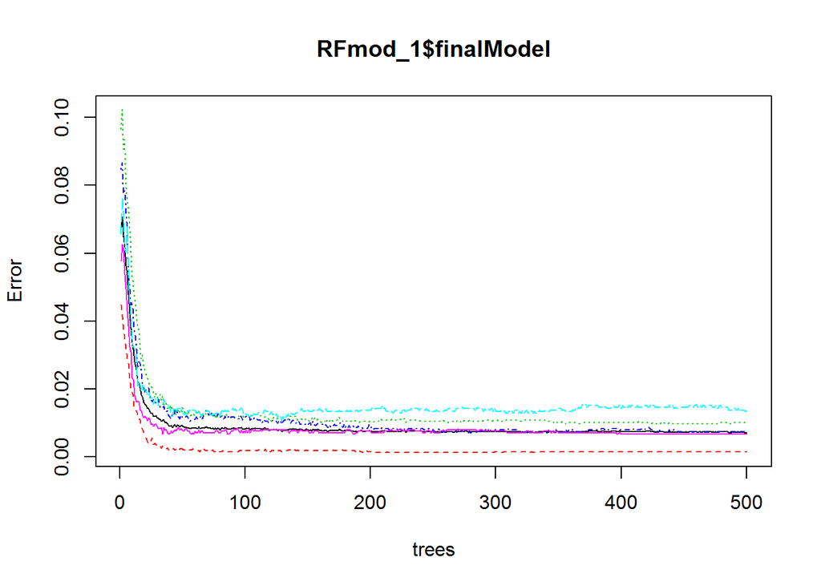

```r
plot(RFmod_1$finalModel)
```

As we can see, around 150 trees the error does not change significantly and it’s almost constant.

#### 2nd Model:

```r
RFmod_2 = randomForest(classe ~ . , data= training)
```

```r
RFmod_2$finalModel
```

[output not shown]

```r
RFpredict_2 = predict(RFmod_2, test)
confusionMatrix(RFpredict_2, test$classe)
```

```
## Confusion Matrix and Statistics
##
##           Reference
## Prediction    A    B    C    D    E
##          A 1672    6    0    0    0
##          B    1 1127    6    0    0
##          C    0    6 1017    8    2
##          D    0    0    3  955    2
##          E    1    0    0    1 1078
##
## Overall Statistics
##
##                Accuracy : 0.9939
##                  95% CI : (0.9915, 0.9957)
##     No Information Rate : 0.2845
##     P-Value [Acc > NIR] : < 2.2e-16
##
##                   Kappa : 0.9923
##  Mcnemar's Test P-Value : NA
##
## Statistics by Class:
##
##                      Class: A Class: B Class: C Class: D Class: E
## Sensitivity            0.9988   0.9895   0.9912   0.9907   0.9963
## Specificity            0.9986   0.9985   0.9967   0.9990   0.9996
## Pos Pred Value         0.9964   0.9938   0.9845   0.9948   0.9981
## Neg Pred Value         0.9995   0.9975   0.9981   0.9982   0.9992
## Prevalence             0.2845   0.1935   0.1743   0.1638   0.1839
## Detection Rate         0.2841   0.1915   0.1728   0.1623   0.1832
## Detection Prevalence   0.2851   0.1927   0.1755   0.1631   0.1835
## Balanced Accuracy      0.9987   0.9940   0.9940   0.9948   0.9979
```

This one has also an accuracy of 99% on the test set.

### Prediction on the testing set:

```r
predict(RFmod_2, testing)
```

```
##  1  2  3  4  5  6  7  8  9 10 11 12 13 14 15 16 17 18 19 20
##  B  A  B  A  A  E  D  B  A  A  B  C  B  A  E  E  A  B  B  B
## Levels: A B C D E
```